# Determinants of Plasma Retinol Concentrations: A Cross-Sectional Study

Abderrezzaq KADOUCHE

## **Study Context**

Epidemiological and observational evidence suggests that lower dietary intake or diminished plasma concentrations of micronutrients -such as retinol, beta-carotene, and other carotenoids- may be correlated with an elevated risk of developing specific malignancies. Despite these observations, the underlying personal and dietary determinants influencing these plasma concentrations remain insufficiently characterized.

To address this gap, **Stukel et al.** conducted a cross-sectional study investigated the relationship between lifestyle characteristics, dietary factors, and the plasma levels of these micronutrients.

## **Study Population & Data Source**

The study cohort comprises 315 patients who underwent elective surgical procedures (biopsy or lesion removal) over a three-year period. All treated lesions –originating from the lung, colon, breast, skin, ovary, or uterus- were histologically confirmed to be non-cancerous.

The analysis presented in this report utilizes a subset of this historical data (originally made available via *StatLib*), focusing specifically on plasma retinol concentrations and its associated demographic and nutritional predictors.

## **Aim**

The purpose of this study is to determine which demographic, lifestyle, and dietary factors are significantly associated with plasma retinol concentrations.

## **Variables Labels:**

- **AGE:** Age (in years)
- **SEXE:** 1=Male, 2=Female
- **TABAC:** 1=Never, 2=Former, 3=Current
- **BMI:** weight/(height²)
- **VITAMINES:** 1=Yes, fairly often, 2=Yes, not often, 3=No
- **CALORIES:** Number of calories per day
- **GRAISSES:** Grams of fat consumed per day
- **FIBRES:** Grams of fiber consumed per day
- **ALCOOL:** Number of alcoholic drinks consumed per week
- **CHOLESTEROL:** Cholesterol consumed (mg per day)
- **BETADIET:** beta-carotene consumed (mcg per day)
- **RETDIET:** retinol consumed (mcg per day)
- **BETAPLASMA:** plasma beta-carotene (ng/ml)
- **RETPLASMA:** Plasma retinol (ng/ml)

## **Descriptive Analysis of Continuous Variables**

```r
tp <- read.csv2("TPretinol.csv")

library (prettyR)

# Variables quantitatives
vars_quanti <- c("age", "bmi", "calories", "graisses", "fibres",
                 "alcool", "cholesterol", "betadiet", "retdiet",
                 "betaplasma", "retplasma")

# Statistiques descriptives
describe(
  tp[, vars_quanti],
  num.desc = c("min", "max", "mean", "median", "sd", "valid.n")
)
```

```
## Description of tp[, vars_quanti]
```

```
##
##  Numeric
##                min    max    mean  median      sd valid.n
## age          19.00   83.0   50.15   48.00   14.58     315
## bmi          16.33   50.4   26.16   24.74    6.01     315
## calories    445.20 6662.2 1796.65 1666.80  680.35     315
## graisses     14.40  235.9   77.03   72.90   33.83     315
## fibres        3.10   36.8   12.79   12.10    5.33     315
## alcool        0.00  203.0    3.28    0.30   12.32     315
## cholesterol  37.70  900.7  242.46  206.30  131.99     315
## betadiet    214.00 9642.0 2185.60 1802.00 1473.89     315
## retdiet      30.00 6901.0  832.71  707.00  589.29     315
## betaplasma    0.00 1415.0  189.89  140.00  183.00     315
## retplasma   179.00 1727.0  602.79  566.00  208.90     315
```

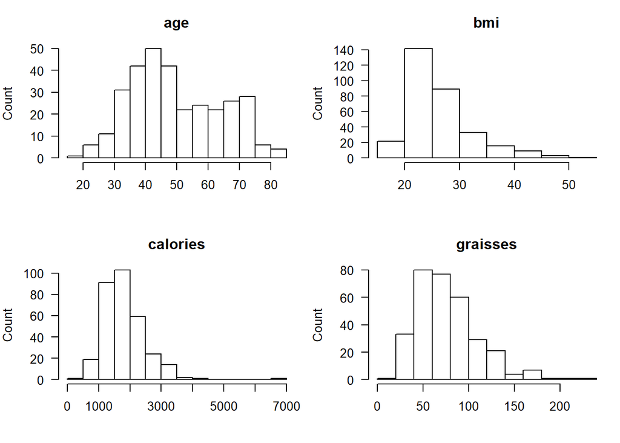

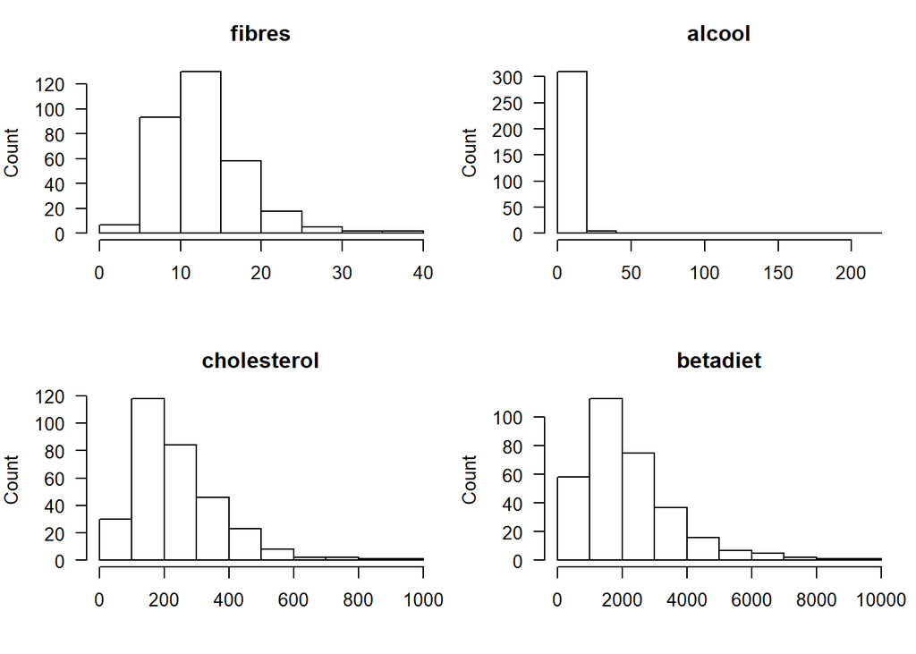

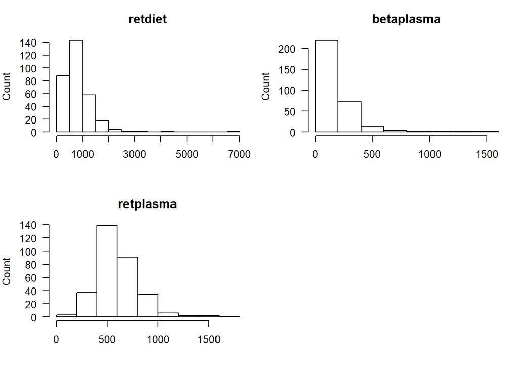

```r
# Grille adaptée : 3 lignes x 4 colonnes = 12 cases (pour 11 variables)
par(mfrow = c(2, 2), mar = c(4, 4, 3, 1))

# Boucle sur toutes les variables quantitatives
for (var in vars_quanti) {
  hist(tp[[var]],
       main = var,              # Titre = nom de la variable
       xlab = "",               # Pas de label sur l'axe X
       ylab = "Count",       # Label Y
       las  = 1,                # Labels horizontaux
       col  = "white",           # barres BLANCHES
       border = "black")         #  contours NOIRS)
}
```

## **Descriptive Analysis of Categorical Variables**

```r
library(gtsummary)

library(dplyr)

tp <- tp %>%
  mutate(
    sexe = factor(sexe, levels = c(1, 2),
                  labels = c("Male", "Female")),

    tabac = factor(tabac, levels = c(1, 2, 3),
                   labels = c("Never", "Former", "Current")),

    vitamine = factor(vitamine, levels = c(1, 2, 3),
                       labels = c("Yes, fairly often",
                                  "Yes, not often",
                                  "No"))
  )

tp %>%
  select(sexe, tabac, vitamine) %>%
  tbl_summary(
    statistic = all_categorical() ~ "{n} ({p}%)",
    digits       = all_categorical() ~ 1,
    label     = list(
      sexe      ~ "Sexe",
      tabac     ~ "Smoking status",
      vitamine ~ "Vitamin intake"
    ),

    missing_text = "Missing"
  ) %>%
  bold_labels()
```

| **Characteristic** | **N = 315**<sup>1</sup> |
| --- | --- |
| Sexe |  |
| Male | 42.0 (13.3%) |
| Female | 273.0 (86.7%) |
| Smoking status |  |
| Never | 157.0 (49.8%) |
| Former | 115.0 (36.5%) |
| Current | 43.0 (13.7%) |
| Vitamin intake |  |
| Yes, fairly often | 122.0 (38.7%) |
| Yes, not often | 82.0 (26.0%) |
| No | 111.0 (35.2%) |

<sup>1</sup> n (%)

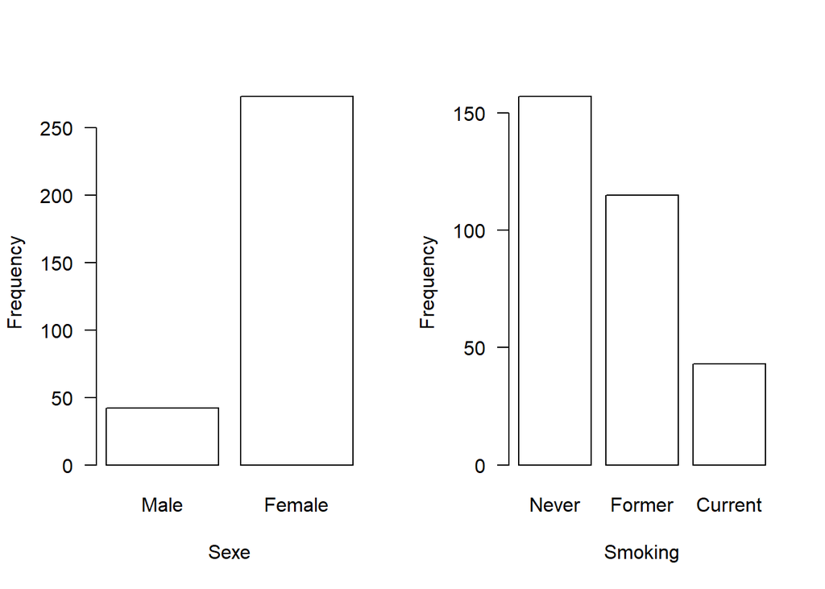

```r
par(mfrow = c(1, 2))

# ── SEXE ──────────────────────────────────────────────
barplot(
  table(tp$sexe),
  ylab      = "Frequency",
  xlab      = "Sexe",
  names.arg = c("Male", "Female"),
  col       = "white",
  border    = "black",
  las       = 1,
  cex.names = 1.0,
  cex.lab   = 1.0
)

# ── TABAC ─────────────────────────────────────────────
barplot(
  table(tp$tabac),
  ylab      = "Frequency",
  xlab      = "Smoking",
  names.arg = c("Never", "Former", "Current"),
  col       = "white",
  border    = "black",
  las       = 1,
  cex.names = 1.0,
  cex.lab   = 1.0
)
```

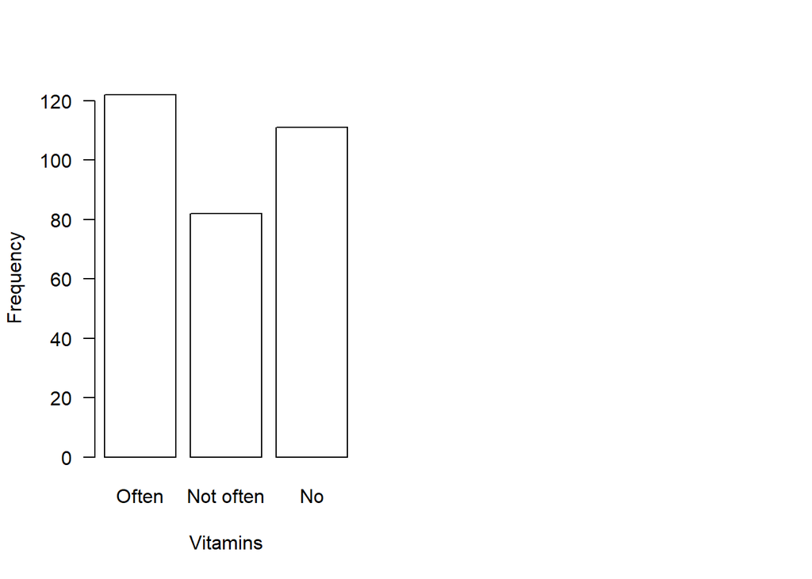

```r
# ── VITAMINES ─────────────────────────────────────────
barplot(
  table(tp$vitamine),
  ylab      = "Frequency",
  xlab      = "Vitamins",
  names.arg = c("Often", "Not often", "No"),
  col       = "white",
  border    = "black",
  las       = 1,
  cex.names = 1.0,
  cex.lab   = 1.0
)
```

## **Is there an association between sex and smoking status ?**

Yes. The Chi-square test shows a statistically significant association between sex and smoking status (p = 0.03). The validity condition was met, as all expected frequencies were greater than 5.

Men were more likely to be former smokers (52% vs 34% in women), while women were more likely to have never smoked (53% vs 31% in men). The proportion of current smokers was slightly higher in men (17%) than in women (13%).

```r
table(tp$sexe,tp$tabac)
```

```
##
##          Never Former Current
##   Male      13     22       7
##   Female   144     93      36
```

```r
round(prop.table(table(tp$sexe, tp$tabac), margin = 1), 2)
```

```
##
##          Never Former Current
##   Male    0.31   0.52    0.17
##   Female  0.53   0.34    0.13
```

```r
chisq.test(tp$sexe,tp$tabac,correct=F)
```

```
##
##  Pearson's Chi-squared test
##
## data:  tp$sexe and tp$tabac
## X-squared = 7.1365, df = 2, p-value = 0.0282
```

## **Is there a statistically significant association between sex and vitamin intake?**

The Chi-square test reveals a statistically significant association between sex and vitamin intake (p = 0.004). The validity condition was satisfied (all expected counts > 5).

Women were more likely to consume vitamins, with 40% reporting “Yes, fairly often” compared to 31% in men. In contrast, men were more likely to report no vitamin intake (57% vs 32% in women). This suggests that women in this study population are more likely to use vitamin supplements than men.

```r
table(tp$sexe,tp$vitamine)
```

```
##
##          Yes, fairly often Yes, not often  No
##   Male                  13              5  24
##   Female               109             77  87
```

```r
round(prop.table(table(tp$sexe,tp$vitamine), margin=1),2)
```

```
##
##          Yes, fairly often Yes, not often   No
##   Male                0.31           0.12 0.57
##   Female              0.40           0.28 0.32
```

```r
chisq.test(tp$sexe,tp$vitamine,correct=F)
```

```
##
##  Pearson's Chi-squared test
##
## data:  tp$sexe and tp$vitamine
## X-squared = 11.071, df = 2, p-value = 0.003944
```

## **Is there a difference in alcohol consumption between men and women?**

After excluding one implausible value for alcohol consumption (203 drinks per week), there was a statistically significant difference between men and women (p = 0.008). Men consumed on average 5.73 drinks per week, compared to 2.18 in women. This result confirms that men consume significantly more alcohol than women in this study population.

```r
# Voir les 10 plus grandes valeurs
sort(tp$alcool, decreasing = TRUE)[1:10] #Retirer la valeur aberrante 203
```

```
##  [1] 203.0  35.0  35.0  22.0  21.0  20.0  18.2  18.0  18.0  17.0
```

```r
tp_clean <- tp[tp$alcool < 36, ]

t.test(alcool ~ sexe, data = tp_clean)
```

```
##
##  Welch Two Sample t-test
##
## data:  alcool by sexe
## t = 2.7589, df = 43.174, p-value = 0.008472
## alternative hypothesis: true difference in means between group Male and group Female is not equal to 0
## 95 percent confidence interval:
##  0.9544646 6.1387543
## sample estimates:
##   mean in group Male mean in group Female
##             5.726829             2.180220
```

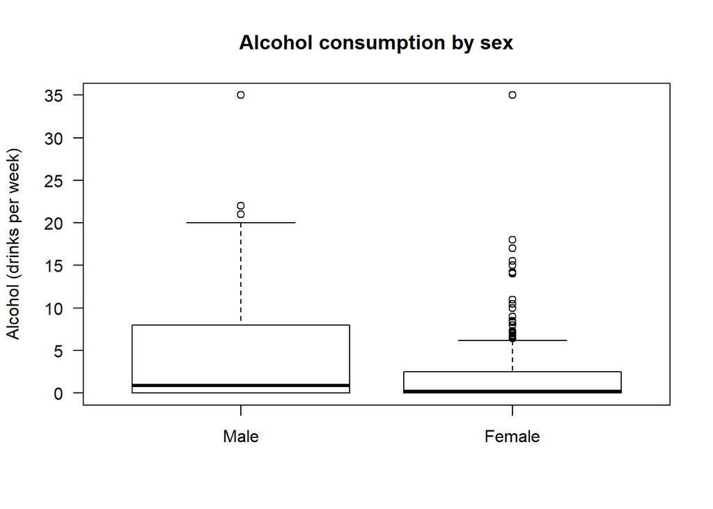

```r
boxplot(alcool ~ sexe, data = tp_clean,
        main   = "Alcohol consumption by sex",
        xlab   = " ",
        ylab   = "Alcohol (drinks per week)",
        col    = "white",
        border = "black",
        las    = 1,
        names  = c("Male", "Female"),
        ylim   = c(0, 35)
       )
```

## **Is there a difference in cholesterol intake between men and women?**

There is a highly statistically significant difference in cholesterol intake between men and women (p < 0.001). Men consumed on average 328 mg/day of cholesterol, compared to 229 mg/day in women which indicates that men consume substantially more cholesterol than women in this study population.

```r
t.test(cholesterol ~ sexe, data = tp)
```

```
##
##  Welch Two Sample t-test
##
## data:  cholesterol by sexe
## t = 4.1739, df = 50.745, p-value = 0.0001174
## alternative hypothesis: true difference in means between group Male and group Female is not equal to 0
## 95 percent confidence interval:
##   51.29455 146.38970
## sample estimates:
##   mean in group Male mean in group Female
##             328.1238             229.2817
```

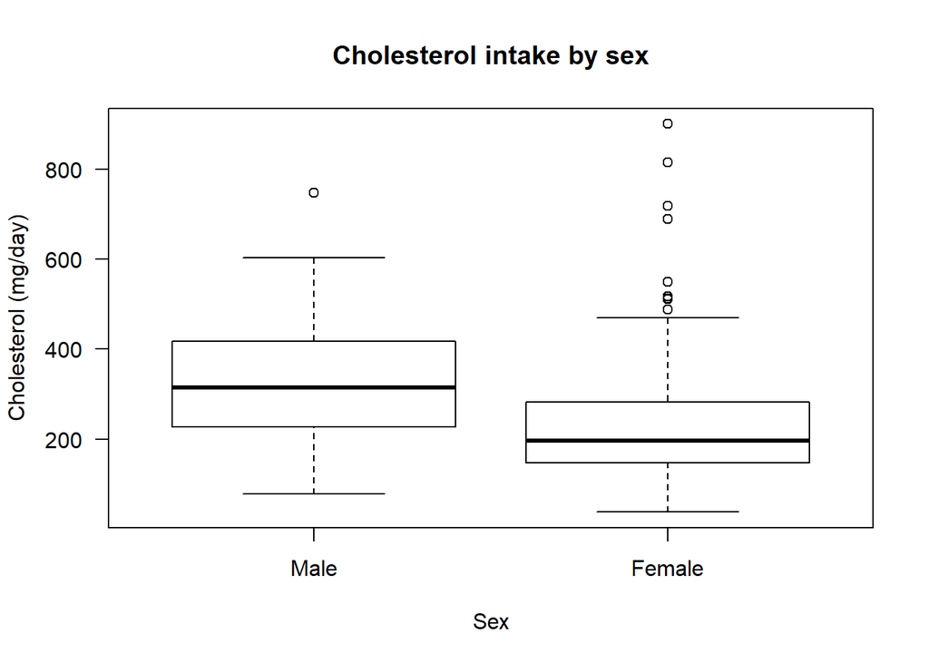

```r
boxplot(cholesterol ~ sexe, data = tp,
        main   = "Cholesterol intake by sex",
        xlab   = "Sex",
        ylab   = "Cholesterol (mg/day)",
        col    = "white",
        border = "black",
        las    = 1,
        names  = c("Male", "Female")
        )
```

## **Is there a difference in plasma retinol concentration between men and women?**

There is a statistically significant difference in plasma retinol concentration between men and women (p = 0.025). Men had a higher mean plasma retinol concentration (701 ng/ml) compared to women (588 ng/ml).

```r
t.test(retplasma ~ sexe, data = tp)
```

```
##
##  Welch Two Sample t-test
##
## data:  retplasma by sexe
## t = 2.3157, df = 45.685, p-value = 0.02512
## alternative hypothesis: true difference in means between group Male and group Female is not equal to 0
## 95 percent confidence interval:
##   14.76117 211.27180
## sample estimates:
##   mean in group Male mean in group Female
##             700.7381             587.7216
```

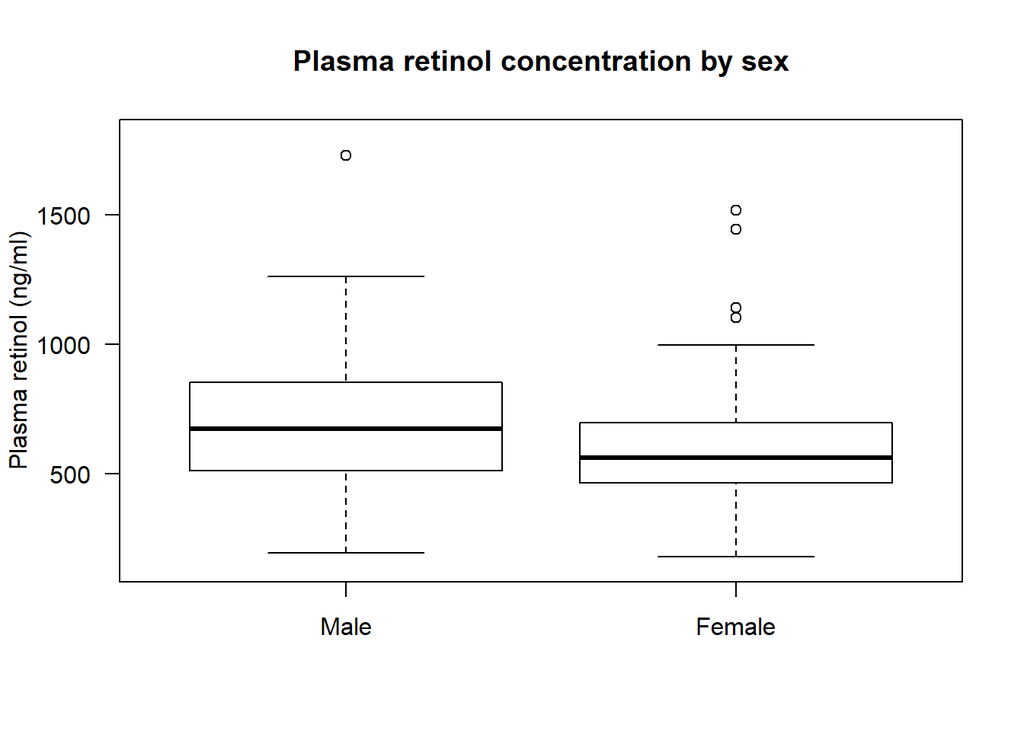

```r
boxplot(retplasma ~ sexe, data = tp,
        main   = "Plasma retinol concentration by sex",
        xlab   = " ",
        ylab   = "Plasma retinol (ng/ml)",
        col    = "white",
        border = "black",
        las    = 1,
        names  = c("Male", "Female"),
        ylim   = c(150, 1800)
)
```

## **Is there a difference in age across smoking status categories?**

Age differed significantly across smoking status categories (p = 0.024). Post-hoc Tukey tests indicated that current smokers were approximately six years younger than both never-smokers (p = 0.021) and former smokers (p = 0.043), while no difference was observed between former and never-smokers (p = 0.97).

```r
anova_tabac <- aov(age ~ tabac, data = tp)
summary(anova_tabac)
```

```
##              Df Sum Sq Mean Sq F value Pr(>F)
## tabac         2   1581   790.6   3.788 0.0237 *
## Residuals   312  65124   208.7
## ---
## Signif. codes:  0 '***' 0.001 '**' 0.01 '*' 0.05 '.' 0.1 ' ' 1
```

```r
TukeyHSD(aov(age ~ tabac, data = tp))
```

```
##   Tukey multiple comparisons of means
##     95% family-wise confidence level
##
## Fit: aov(formula = age ~ tabac, data = tp)
##
## $tabac
##                      diff        lwr        upr     p adj
## Former-Never   -0.4490169  -4.625026  3.7269922 0.9652769
## Current-Never  -6.6880462 -12.544122 -0.8319706 0.0205493
## Current-Former -6.2390293 -12.320675 -0.1573835 0.0428688
```

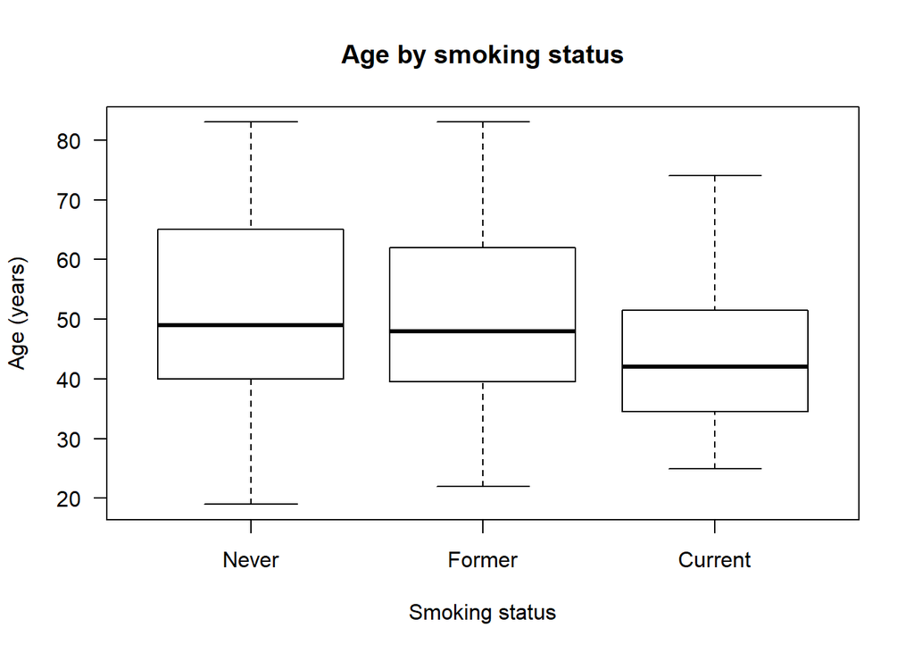

```r
boxplot(age ~ tabac, data = tp,
        main   = "Age by smoking status",
        xlab   = "Smoking status",
        ylab   = "Age (years)",
        col    = "white",
        border = "black",
        las    = 1,
        names  = c("Never", "Former", "Current"))
```

## **Is there a difference in age across vitamin intake categories?**

Age differed significantly across vitamin intake categories (p = 0.013). Post-hoc Tukey tests indicated that occasional vitamin users were approximately five years younger than both regular users (p = 0.018) and non-users (p = 0.03), while no age difference was observed between regular users and non-users (p = 0.99).

```r
anova_vit <- aov(age ~ vitamine, data = tp)
summary(anova_vit)
```

```
##              Df Sum Sq Mean Sq F value Pr(>F)
## vitamine      2   1844   921.8   4.434 0.0126 *
## Residuals   312  64862   207.9
## ---
## Signif. codes:  0 '***' 0.001 '**' 0.01 '*' 0.05 '.' 0.1 ' ' 1
```

```r
TukeyHSD(aov(age ~ vitamine, data = tp))
```

```
##   Tukey multiple comparisons of means
##     95% family-wise confidence level
##
## Fit: aov(formula = age ~ vitamine, data = tp)
##
## $vitamine
##                                        diff         lwr        upr     p adj
## Yes, not often-Yes, fairly often -5.6399440 -10.4886713 -0.7912167 0.0178414
## No-Yes, fairly often             -0.2806823  -4.7345373  4.1731726 0.9879312
## No-Yes, not often                 5.3592617   0.4149055 10.3036179 0.0299607
```

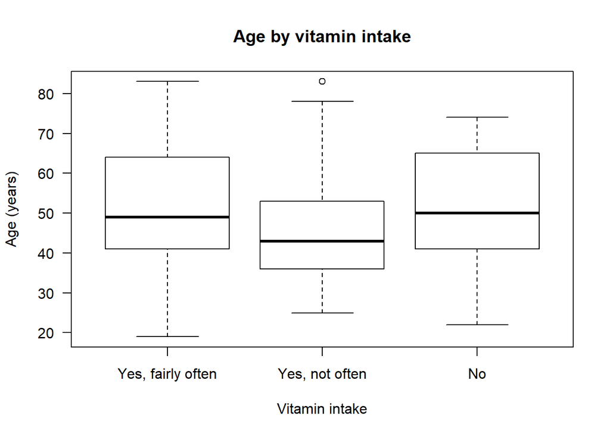

```r
boxplot(age ~ vitamine, data = tp,
        main   = "Age by vitamin intake",
        xlab   = "Vitamin intake",
        ylab   = "Age (years)",
        col    = "white",
        border = "black",
        las    = 1,
        names  = c("Yes, fairly often", "Yes, not often", "No"))
```

## **Model Estimation and Results**

To answer the research question, a multivariable linear regression approach was selected. This method evaluates the simultaneous effect of multiple demographic, lifestyle, and dietary factors on continuous plasma retinol levels.

```r
mod <-lm(retplasma~age+sexe+tabac+bmi+vitamine+alcool+cholesterol+retdiet, data=tp)

summary(mod)
```

```
##
## Call:
## lm(formula = retplasma ~ age + sexe + tabac + bmi + vitamine +
##     alcool + cholesterol + retdiet, data = tp)
##
## Residuals:
##     Min      1Q  Median      3Q     Max
## -493.15 -127.91  -24.68  105.03  996.07
##
## Coefficients:
##                         Estimate Std. Error t value Pr(>|t|)
## (Intercept)            578.50193   90.35333   6.403 5.78e-10 ***
## age                      2.26446    0.85257   2.656  0.00832 **
## sexeFemale             -98.17895   37.96318  -2.586  0.01017 *
## tabacFormer             58.07162   25.33008   2.293  0.02255 *
## tabacCurrent             1.12252   36.59076   0.031  0.97555
## bmi                      1.11956    1.94346   0.576  0.56500
## vitamineYes, not often  -0.89656   29.40919  -0.030  0.97570
## vitamineNo             -31.25119   27.33122  -1.143  0.25376
## alcool                  -0.07388    0.97529  -0.076  0.93967
## cholesterol             -0.13209    0.10385  -1.272  0.20439
## retdiet                 -0.01357    0.02174  -0.624  0.53293
## ---
## Signif. codes:  0 '***' 0.001 '**' 0.01 '*' 0.05 '.' 0.1 ' ' 1
##
## Residual standard error: 202.1 on 304 degrees of freedom
## Multiple R-squared:  0.09348,    Adjusted R-squared:  0.06366
## F-statistic: 3.135 on 10 and 304 DF,  p-value: 0.0007875
```

## **Checking Residuals Normality**

We can therefore conclude that the linear regression model is valid.

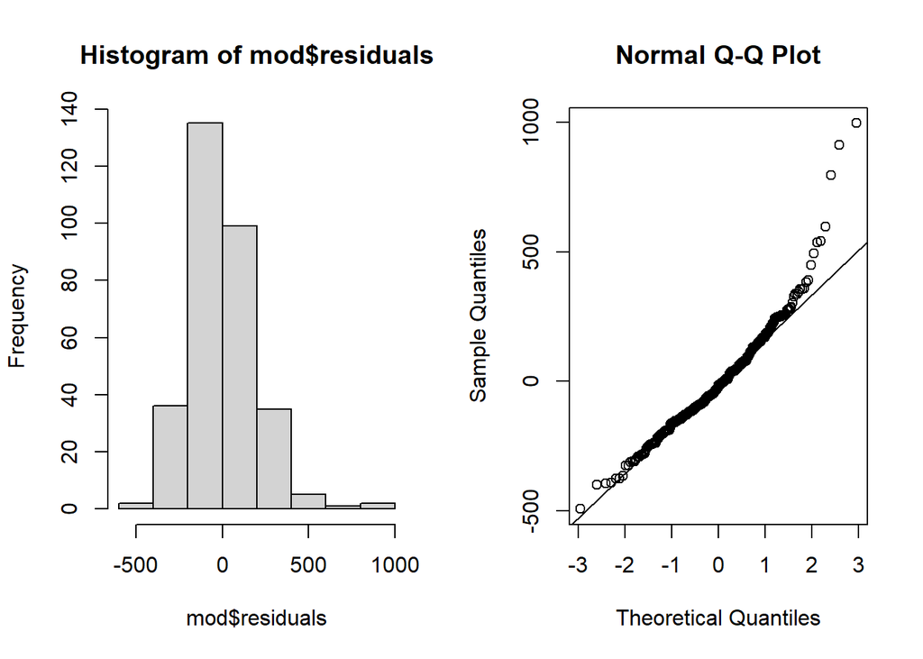

```r
#vérification de la normalité des résidus

par(mfrow=c(1,2)); #permet de mettre 2 graphiques côte à côte

hist(mod$residuals)

qqnorm(mod$residuals)

qqline(mod$residuals)
```

## **Conclusion**

Age was positively associated with plasma retinol, with an increase of 2.26 ng/ml per additional year of age (p = 0.008).

Sex was also significantly associated with plasma retinol: women had, on average, a plasma retinol concentration 98.18 ng/ml lower than men (p = 0.010), holding other factors constant.